# Medical Insurance Cost Personal Datasets

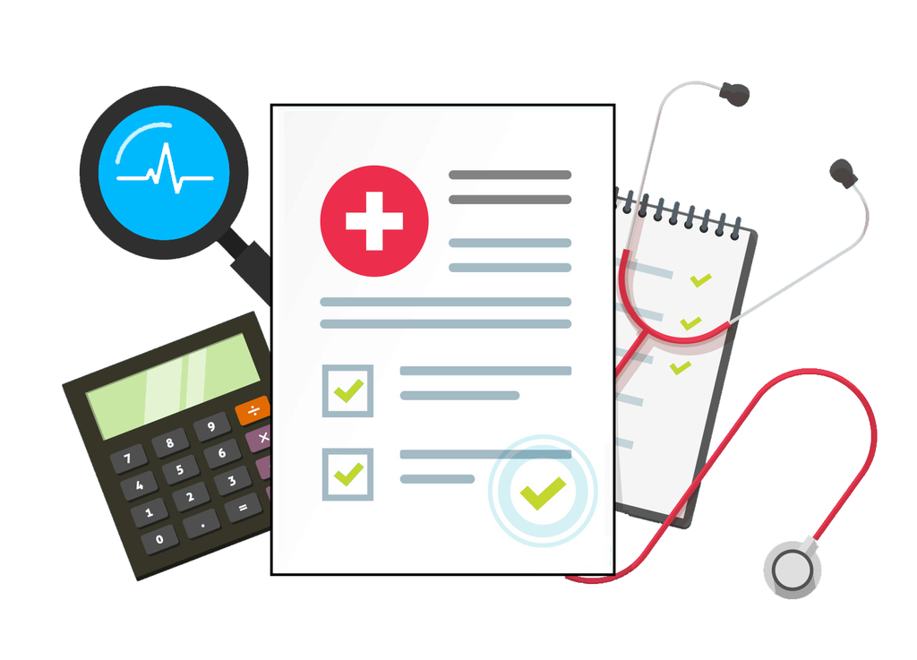

## 1. Setup

```python
import numpy as np
import pandas as pd
import matplotlib.pyplot as plt
%matplotlib inline
import seaborn as sns
from prettytable import PrettyTable
```

## 2. Read & Load Data

```python
#Reading and loading data from csv
df = pd.read_csv('insurance.csv')
df
```

|  | age | sex | bmi | children | smoker | region | charges |
| --- | --- | --- | --- | --- | --- | --- | --- |
| 0 | 19 | female | 27.900 | 0 | yes | southwest | 16884.92400 |
| 1 | 18 | male | 33.770 | 1 | no | southeast | 1725.55230 |
| 2 | 28 | male | 33.000 | 3 | no | southeast | 4449.46200 |
| 3 | 33 | male | 22.705 | 0 | no | northwest | 21984.47061 |
| 4 | 32 | male | 28.880 | 0 | no | northwest | 3866.85520 |
| ... | ... | ... | ... | ... | ... | ... | ... |
| 1333 | 50 | male | 30.970 | 3 | no | northwest | 10600.54830 |
| 1334 | 18 | female | 31.920 | 0 | no | northeast | 2205.98080 |
| 1335 | 18 | female | 36.850 | 0 | no | southeast | 1629.83350 |
| 1336 | 21 | female | 25.800 | 0 | no | southwest | 2007.94500 |
| 1337 | 61 | female | 29.070 | 0 | yes | northwest | 29141.36030 |

1338 rows × 7 columns

## 3. View First & Last Five Data

```python
#first five rows
df.head()
```

|  | age | sex | bmi | children | smoker | region | charges |
| --- | --- | --- | --- | --- | --- | --- | --- |
| 0 | 19 | female | 27.900 | 0 | yes | southwest | 16884.92400 |
| 1 | 18 | male | 33.770 | 1 | no | southeast | 1725.55230 |
| 2 | 28 | male | 33.000 | 3 | no | southeast | 4449.46200 |
| 3 | 33 | male | 22.705 | 0 | no | northwest | 21984.47061 |
| 4 | 32 | male | 28.880 | 0 | no | northwest | 3866.85520 |

```python
#last five rows
df.tail()
```

|  | age | sex | bmi | children | smoker | region | charges |
| --- | --- | --- | --- | --- | --- | --- | --- |
| 1333 | 50 | male | 30.97 | 3 | no | northwest | 10600.5483 |
| 1334 | 18 | female | 31.92 | 0 | no | northeast | 2205.9808 |
| 1335 | 18 | female | 36.85 | 0 | no | southeast | 1629.8335 |
| 1336 | 21 | female | 25.80 | 0 | no | southwest | 2007.9450 |
| 1337 | 61 | female | 29.07 | 0 | yes | northwest | 29141.3603 |

## 4. Data exploration

```python
#df.shape
print("Number of samples:", df.shape[0])
print("Number of attributes:", df.shape[1])
```

```
Number of samples: 1338
Number of attributes: 7
```

```python
df.info()
```

```
<class 'pandas.core.frame.DataFrame'>
RangeIndex: 1338 entries, 0 to 1337
Data columns (total 7 columns):
 #   Column    Non-Null Count  Dtype
---  ------    --------------  -----
 0   age       1338 non-null   int64
 1   sex       1338 non-null   object
 2   bmi       1338 non-null   float64
 3   children  1338 non-null   int64
 4   smoker    1338 non-null   object
 5   region    1338 non-null   object
 6   charges   1338 non-null   float64
dtypes: float64(2), int64(2), object(3)
memory usage: 73.3+ KB
```

```python
df.describe()
```

|  | age | bmi | children | charges |
| --- | --- | --- | --- | --- |
| count | 1338.000000 | 1338.000000 | 1338.000000 | 1338.000000 |
| mean | 39.207025 | 30.663397 | 1.094918 | 13270.422265 |
| std | 14.049960 | 6.098187 | 1.205493 | 12110.011237 |
| min | 18.000000 | 15.960000 | 0.000000 | 1121.873900 |
| 25% | 27.000000 | 26.296250 | 0.000000 | 4740.287150 |
| 50% | 39.000000 | 30.400000 | 1.000000 | 9382.033000 |
| 75% | 51.000000 | 34.693750 | 2.000000 | 16639.912515 |
| max | 64.000000 | 53.130000 | 5.000000 | 63770.428010 |

```python
df.isnull().sum()
```

```
age         0
sex         0
bmi         0
children    0
smoker      0
region      0
charges     0
dtype: int64
```

```python
missing_values_table = PrettyTable()

missing_values_table.field_names = ["Attribute", "Missing values"]

for attribute, count in df.isnull().sum().iteritems():
    missing_values_table.add_row([attribute, count])

print(missing_values_table)
```

```
+-----------+----------------+
| Attribute | Missing values |
+-----------+----------------+
|    age    |       0        |
|    sex    |       0        |
|    bmi    |       0        |
|  children |       0        |
|   smoker  |       0        |
|   region  |       0        |
|  charges  |       0        |
+-----------+----------------+
```

## Exploring the Sample Data Visually

```python
male = df[df['sex']=='male']
female = df[df['sex']=='female']
print('sample male count= ',male.size)
print('sample female count= ',female.size)
```

```
sample male count=  4732
sample female count=  4634
```

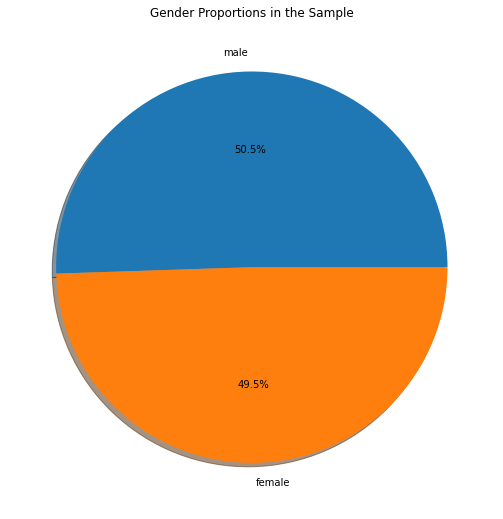

```python
labels = ['male','female']
sizes = [df[df['sex']=='male'].size, df[df['sex']=='female'].size]
plt.figure(figsize=(16,9))
plt.pie(sizes, labels=labels, autopct='%1.1f%%',shadow=True)
tt = 'Gender Proportions in the Sample'
plt.title(tt)
plt.show()
```

## This pie chart shows how we have practically the same number of samples from both gender.

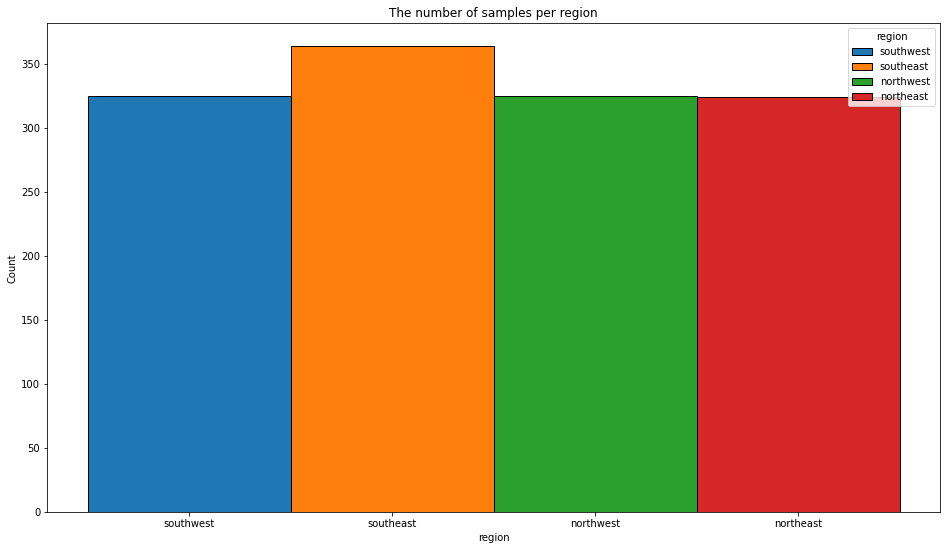

```python
plt.figure(figsize=(16,9))
plt.title('The number of samples per region')
sns.histplot(data=df,x='region',hue='region', color='bright', alpha=1)
```

## The histogram above shows the distribution of the samples per region variable inside the insurance dataframe. The sample size is more from the southeast region over other regions.

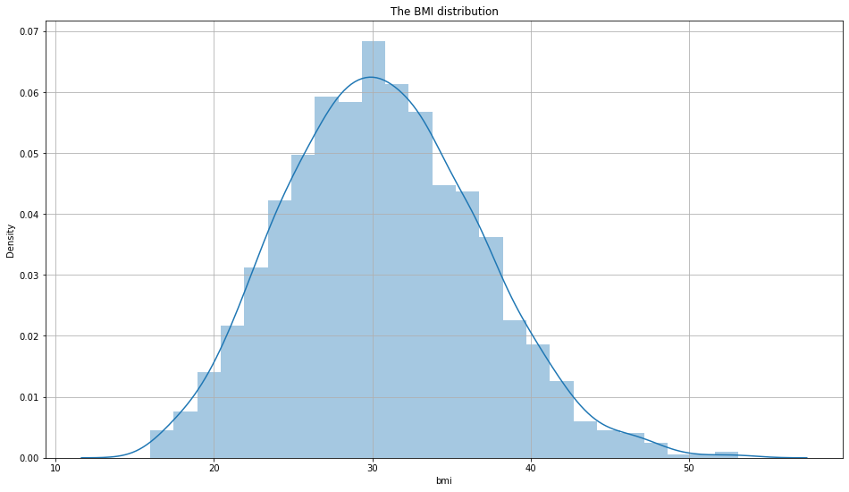

```python
# We take all the 'BMI' attribute values.
b=df['bmi'].dropna()
plt.figure(figsize=(16,9))
plt.title('The BMI distribution')
sns.distplot(b)
plt.grid(True)
plt.show()
```

## As we can observe, the BMI attribute has a normal distribution.

### The bmi attribute is complicated to understand just with numbers, lets try to group the values in order to know the weight status of the samples.

In order to calculate the weight status we are going to consider the following groups:

Underweight: BMI is less than 18.5. Normal: BMI is 18.5 to 24.9. Overweight: BMI is 25 to 29.9. Obese: BMI is 30 or more.

```python
# We define the function that classifies the BMI in different weight status.
def get_weight_status(bmi):
    if bmi < 18.5:
        status = "Underweight"
    elif bmi < 25:
        status = "Normal"
    elif bmi < 30:
        status = "Overweight"
    else:
        status = "Obese"
    return status


# We generate a new attribute that indicates the weight status.
df['weight_status'] = df['bmi'].apply(get_weight_status)
df
```

|  | age | sex | bmi | children | smoker | region | charges | weight_status |
| --- | --- | --- | --- | --- | --- | --- | --- | --- |
| 0 | 19 | female | 27.900 | 0 | yes | southwest | 16884.92400 | Overweight |
| 1 | 18 | male | 33.770 | 1 | no | southeast | 1725.55230 | Obese |
| 2 | 28 | male | 33.000 | 3 | no | southeast | 4449.46200 | Obese |
| 3 | 33 | male | 22.705 | 0 | no | northwest | 21984.47061 | Normal |
| 4 | 32 | male | 28.880 | 0 | no | northwest | 3866.85520 | Overweight |
| ... | ... | ... | ... | ... | ... | ... | ... | ... |
| 1333 | 50 | male | 30.970 | 3 | no | northwest | 10600.54830 | Obese |
| 1334 | 18 | female | 31.920 | 0 | no | northeast | 2205.98080 | Obese |
| 1335 | 18 | female | 36.850 | 0 | no | southeast | 1629.83350 | Obese |
| 1336 | 21 | female | 25.800 | 0 | no | southwest | 2007.94500 | Overweight |
| 1337 | 61 | female | 29.070 | 0 | yes | northwest | 29141.36030 | Overweight |

1338 rows × 8 columns

[figure not shown]

```python
# We take the 'Weight status' attribute values and the corresponding counts.
labels = df['weight_status'].unique()
values = df['weight_status'].value_counts() #sizes

# We generate the pie chart of the 'Weight status' attribute.
plt.figure(figsize=(16,9))
plt.pie(values, labels=labels, autopct='%1.1f%%',shadow=True)
tt = 'BMI distribution according to the weight status'
plt.title(tt)
plt.legend(labels, loc="best")
plt.show()
```

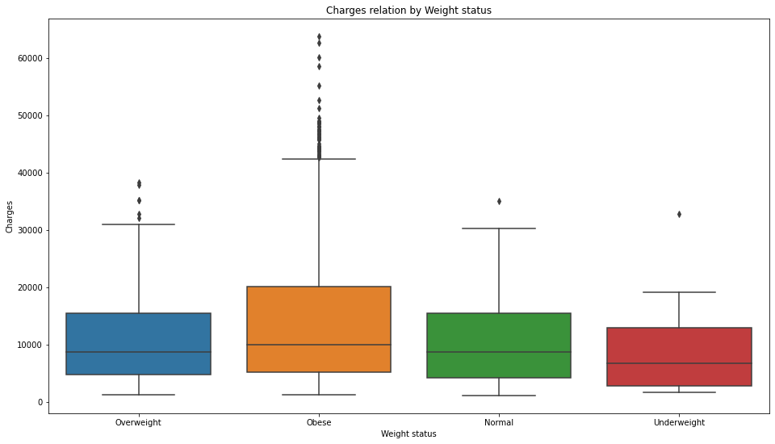

```python
#Insurance companies calculate the charges depending on the impact and probability yo happen of different risks.
#That is why we can expect weight status to be an important fact. To verify this, we are going to see
#the relationship between the charges and this weight status:
plt.figure(figsize=(16,9))
sns.boxplot( x=df["weight_status"], y=df["charges"]);
plt.title('Charges relation by Weight status')
plt.xlabel('Weight status')
plt.ylabel('Charges')

plt.show()
```

### As we expected, the weight status plays an important role when calculating the charges. we can clearly see the fact that the more unhealthy the person is the higher the charges are.

```python
# We define the function that classifies ages.
def get_age_group(age):
    if age < 30:
        category = "Young"
    elif age < 60:
        category = "Adult"
    else:
        category = "Elder"
    return category

# We generate a new attribute that indicates the age group.
df['age_group'] = df['age'].apply(get_age_group)
df
```

|  | age | sex | bmi | children | smoker | region | charges | weight_status | age_group |
| --- | --- | --- | --- | --- | --- | --- | --- | --- | --- |
| 0 | 19 | female | 27.900 | 0 | yes | southwest | 16884.92400 | Overweight | Young |
| 1 | 18 | male | 33.770 | 1 | no | southeast | 1725.55230 | Obese | Young |
| 2 | 28 | male | 33.000 | 3 | no | southeast | 4449.46200 | Obese | Young |
| 3 | 33 | male | 22.705 | 0 | no | northwest | 21984.47061 | Normal | Adult |
| 4 | 32 | male | 28.880 | 0 | no | northwest | 3866.85520 | Overweight | Adult |
| ... | ... | ... | ... | ... | ... | ... | ... | ... | ... |
| 1333 | 50 | male | 30.970 | 3 | no | northwest | 10600.54830 | Obese | Adult |
| 1334 | 18 | female | 31.920 | 0 | no | northeast | 2205.98080 | Obese | Young |
| 1335 | 18 | female | 36.850 | 0 | no | southeast | 1629.83350 | Obese | Young |
| 1336 | 21 | female | 25.800 | 0 | no | southwest | 2007.94500 | Overweight | Young |
| 1337 | 61 | female | 29.070 | 0 | yes | northwest | 29141.36030 | Overweight | Elder |

1338 rows × 9 columns

[figure not shown]

```python
# We take the 'Age group' attribute values and the corresponding counts.
labels = df['age_group'].unique()
values = df['age_group'].value_counts()

plt.figure(figsize=(16,9))
plt.title('Age Proportions')
# We generate the pie chart of the 'Weight status' attribute.
plt.pie(values, labels=labels, autopct='%1.1f%%',shadow=True)
plt.legend(labels, loc="best")
plt.show()
```

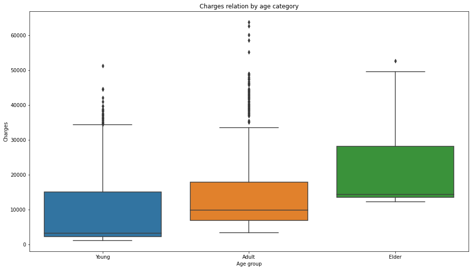

```python
plt.figure(figsize=(16,9))
sns.boxplot( x=df["age_group"], y=df["charges"]);
plt.title('Charges relation by age category')
plt.xlabel('Age group')
plt.ylabel('Charges')
plt.show()
```

### As we expected, there is a correlation between this two attributes: the older the person is the higher the charges are.

## Analyzing the Data by Smoking Habit

```python
smoker = df[df['smoker'] == 'yes'][['bmi', 'charges']].reset_index()
smoker
```

|  | index | bmi | charges |
| --- | --- | --- | --- |
| 0 | 0 | 27.900 | 16884.92400 |
| 1 | 11 | 26.290 | 27808.72510 |
| 2 | 14 | 42.130 | 39611.75770 |
| 3 | 19 | 35.300 | 36837.46700 |
| 4 | 23 | 31.920 | 37701.87680 |
| ... | ... | ... | ... |
| 269 | 1313 | 34.700 | 36397.57600 |
| 270 | 1314 | 23.655 | 18765.87545 |
| 271 | 1321 | 26.695 | 28101.33305 |
| 272 | 1323 | 40.370 | 43896.37630 |
| 273 | 1337 | 29.070 | 29141.36030 |

274 rows × 3 columns

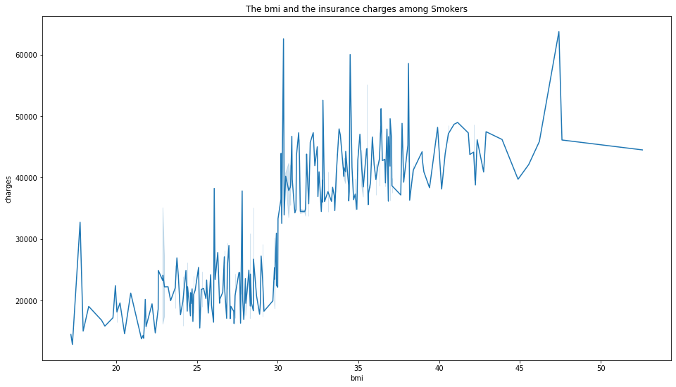

```python
plt.figure(figsize=(16,9))
plt.title('The bmi and the insurance charges among Smokers')
sns.lineplot(x='bmi', y='charges',data=smoker)
```

```python
nonsmoker = df[df['smoker'] == 'no'][['bmi', 'charges']].reset_index()
nonsmoker
```

|  | index | bmi | charges |
| --- | --- | --- | --- |
| 0 | 1 | 33.770 | 1725.55230 |
| 1 | 2 | 33.000 | 4449.46200 |
| 2 | 3 | 22.705 | 21984.47061 |
| 3 | 4 | 28.880 | 3866.85520 |
| 4 | 5 | 25.740 | 3756.62160 |
| ... | ... | ... | ... |
| 1059 | 1332 | 44.700 | 11411.68500 |
| 1060 | 1333 | 30.970 | 10600.54830 |
| 1061 | 1334 | 31.920 | 2205.98080 |
| 1062 | 1335 | 36.850 | 1629.83350 |
| 1063 | 1336 | 25.800 | 2007.94500 |

1064 rows × 3 columns

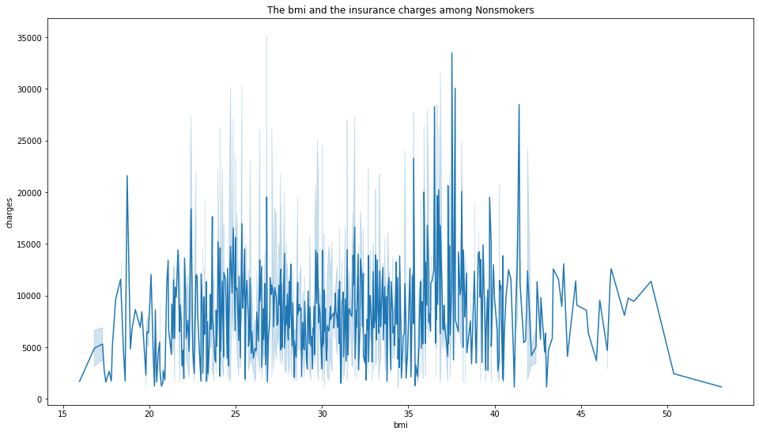

```python
plt.figure(figsize=(16,9))
plt.title('The bmi and the insurance charges among Nonsmokers')
sns.lineplot(x='bmi', y='charges', data=nonsmoker)
```

## From the line plots above, we notice that insurance charges cost higher with increasing bmi among smokers than non-smokers.

## Visualize the data

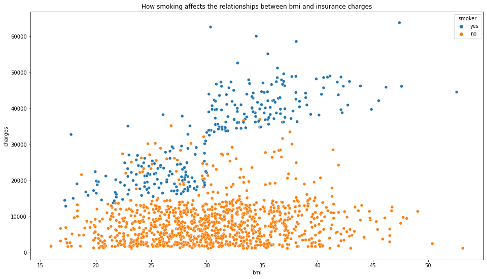

```python
#Understanding how smoking affects the relationships between bmi and insurance charges
#We will use scatterplot to display the relationships between the three variables, one way to do is color coding the points.
#we will color code the points by smoker and plot the other two columns on the axes
plt.figure(figsize=(16,9))
plt.title('How smoking affects the relationships between bmi and insurance charges')
sns.scatterplot(x = df['bmi'], y = df['charges'], hue = df['smoker'])
```

### The scatter plot shows that while nonsmokers to tend to pay slightly more with increasing BMI, smokers pay much more.

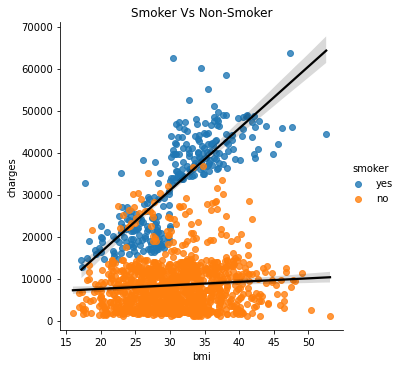

```python
sns.lmplot(x="bmi", y="charges", hue="smoker", data=df, line_kws={'color': 'black'})
plt.title('Smoker Vs Non-Smoker')
```

## In the figure above, we use the sns.lmplot command to add two regression lines, corresponding to smokers and nonsmokers. The regression line for smokers has a much steeper slope, relative to the line for nonsmokers indicating higher charges with increasing bmi.

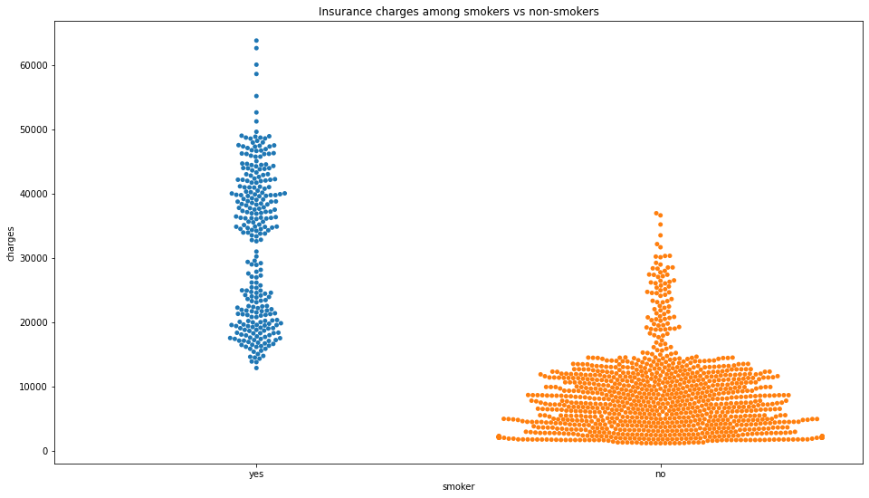

```python
#We'll refer to this plot type as a categorical scatter plot, and we build it with the sns.swarmplot command.
plt.figure(figsize=(16,9))
plt.title('Insurance charges among smokers vs non-smokers')
sns.swarmplot(x=df['smoker'], y=df['charges'])
```

## Above plot shows us that: the customers who pay the most are smokers; whereas the customers who pay the least are non-smokers.

```python
#It would also be interesting to look at the average medical cost for each smoker group:
round(df.groupby(['smoker','sex'])['charges'].mean(),2).to_frame()
```

| smoker | sex | charges |
| --- | --- | --- |
| no | female | 8762.30 |
|  | male | 8087.20 |
| yes | female | 30679.00 |
|  | male | 33042.01 |

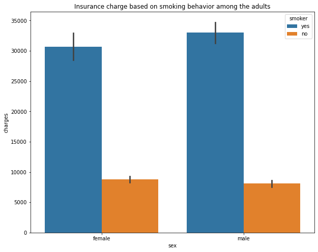

```python
plt.figure(figsize=(10,8))
plt.title('Insurance charge based on smoking behavior among the adults')
sns.barplot(x='sex', y='charges',hue='smoker',data=df)
```

## Analysis : The male and female population are charged similar increasing insurance cost respectively based on whether they smoke or not

```python
#Another thing we can do in order to analyze our data is plotting all the relations between attributes:
```

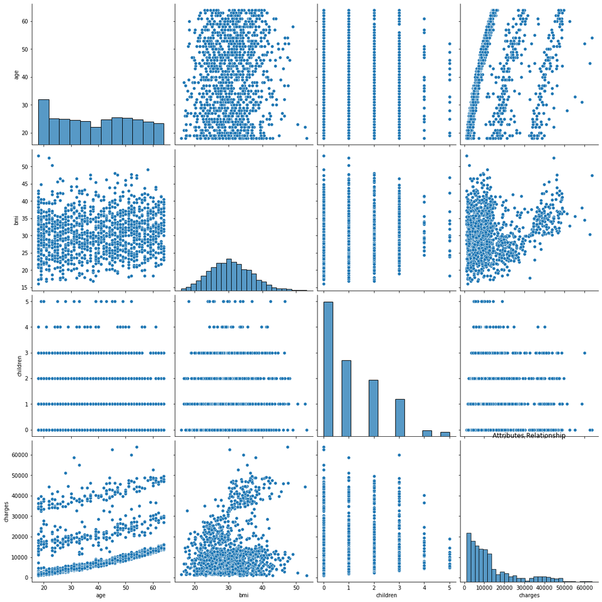

```python
df1=df.drop(['age_group', 'weight_status'], axis=1)
plt.figure(figsize=(16,9))
#sns.pairplot(df1, height=4, hue="charges")
sns.pairplot(df1, height=4)
height=1.5
plt.title('Attributes Relationship')
plt.show()
```